# NHANES 2017-18 Analyses of Associations from Demographic, Examination, and Questionnaire Data

## 4.3 Main Analysis

Based on the data description above, I think that some assumptions can be made that allow us to use the pooled t.test. First, I believe we are safe to assume independence due to nature of separation by WHQ070. I also believe we are safe to assume that each group represent’s a random sample. Based on the visual analysis and skew value, I feel safe assuming normality. Lastly, numerical summaries of distributions also seem safe in assuming both groups have equal variances.

Based on this, code below will use pooled t. test with a 90% confidence interval. Estimate is a comparison of No group minus Yes group.

```r
t.test(BMXHT ~ WHQ070, data = study1_b, conf.level=.90, var.equal=TRUE) %>%
  tidy() %>%
  mutate(estimate = estimate1 - estimate2) %>%
  select(estimate, conf.low, conf.high) %>%
  kable(digits=3)
```

| estimate | conf.low | conf.high |
| --- | --- | --- |
| -1.916 | -2.42 | -1.411 |

The mean height of those who tried to lose weight last year is 1.916 cm. lower than those that did not try to lose weight for this data. We are 90% confident the true difference mean difference in height is between -2.42 cm. and -1.411 cm.

## 4.4 Conclusions

At the 10% significance level, based on this sample data from NHANES 17-18, there appears to be a statistically detectable difference in mean height for individual’s that tried to lose weight versus individual that did not try to lose weight with an estimated mean difference at 1.916 cm. This was determined based on a pooled t. test in a complete case analysis. Based on visualizations presented above, this comparison appears to make sense as the distribution of height for individuals who tried to lose weight last year appeared slightly more right skewed. This result also supports my initial hypothesis that the mean height of those who tried to lose weight last year is lower. However, it should be noted that the statistically detectable difference is less than 2 cm. With mean heights around 166 cm for each group, this is a very small amount, and as far as I am concerned is negligible.

Further steps in this analysis would be to identify confounders and adjust for that. We could attempt to match genders as this is more than likely an impactful confounder. Women are generally shorter and may face more societal pressures for body image that cause them to want to lose weight.

# 5 Analysis C: Comparing 3+ Means with ANOVA

## 5.1 Research Question

### 5.1.1 Research Question: Do groups who rate their general health higher display a higher mean height than groups that rate their general health poor?

## 5.2 Describe Data

My first step in describing the data for this analysis is to assess missing variables. I do this first to see if I will need to do a complete case analysis when later cleaning the data specific for this study.

```r
miss_var_summary(study1)
```

```
# A tibble: 10 x 3
   variable n_miss pct_miss
   <chr>     <int>    <dbl>
 1 WHQ070      679    13.2
 2 DPQ010      368     7.14
 3 HSD010      346     6.72
 4 BMXHT        65     1.26
 5 SEQN          0     0
 6 RIDSTATR      0     0
 7 RIDAGEYR      0     0
 8 SMQ020        0     0
 9 DMQMILIZ      0     0
10 DBQ700        0     0
```

I subset `study1` to a dataset consisting of only the appropriate variables, which include demographic information, `BMXHT`, and `HSD010`. I also filter by complete cases and answers that are considered missing.

```r
study1_c <- study1 %>%
  filter(complete.cases(BMXHT, HSD010),
         HSD010 != "M") %>%
  select(SEQN, RIDSTATR, RIDAGEYR, BMXHT, HSD010)

study1_c <- study1_c %>% droplevels()
```

```r
mosaic::favstats(BMXHT ~ HSD010, data = study1_c)
```

```
     HSD010   min    Q1 median     Q3   max     mean        sd    n missing
1 Excellent 143.6 161.7  168.3 175.50 195.8 168.4626  9.808498  425       0
2 Very Good 142.9 160.3  167.3 175.15 197.7 167.8057  9.829206 1147       0
3      Good 138.3 159.1  166.2 173.70 195.5 166.4804  9.928146 2004       0
4      Fair 141.5 158.3  165.1 173.50 194.6 165.8553 10.189461 1026       0
5      Poor 144.2 158.6  163.9 172.60 194.6 165.5583 10.393490  156       0
```

Below is a visualization of the height distribution by general health condition groups. We can see a few minor outliers in the Poor and Very good category, and all groups appear relatively normal with constant variance as well.

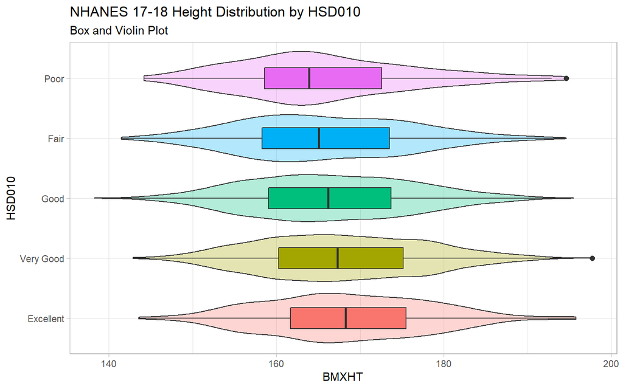

```r
ggplot(study1_c, aes(x = HSD010, y = BMXHT, fill = HSD010)) +
  geom_violin(alpha = 0.3) +
  geom_boxplot(width = 0.35, outlier.size = 2) +
  labs(title = "NHANES 17-18 Height Distribution by HSD010",
       subtitle = "Box and Violin Plot") +
  coord_flip() +
  guides(fill = FALSE) +
  theme_light()
```

A further visualization below also shows distributions of height by general health groups. I think this also supports the idea that each group fits a relatively normal distribution. **Note:** Groups do not all have the same number of observations, and histograms have a free y axis. The poor and excellent categories display a lower number of observations when compared to the other two groups.

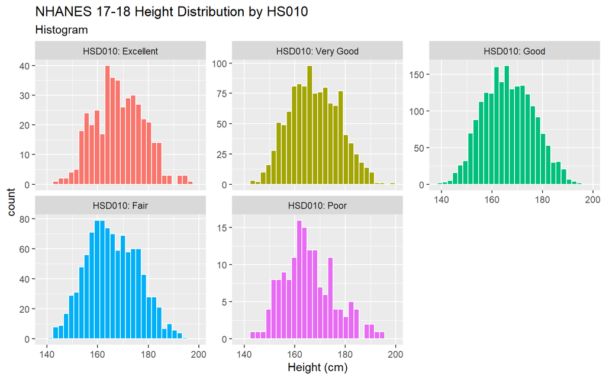

```r
ggplot(study1_c, aes(x = BMXHT, fill = HSD010)) +
  geom_histogram(aes(fill = HSD010), col = "white") +
  facet_wrap(~ HSD010, labeller = "label_both", scales = "free_y") +
  guides(fill = FALSE) +
  labs(title = "NHANES 17-18 Height Distribution by HS010",
       subtitle = "Histogram",
       x = "Height (cm)")
```

## 5.3 Main Analysis

### 5.3.1 ANOVA

For this analysis, I chose to do an analysis of variance because I believe this data fits the necessary assumptions. The p. value suggests there is a statistically detectable difference in means for the general health categories. However, this model accounts for less than 1% of variance for the outcome, which is height.

```r
study1_c %$%
  lm(BMXHT ~ HSD010) %>%
  anova()
```

```
Analysis of Variance Table

Response: BMXHT
            Df Sum Sq Mean Sq F value    Pr(>F)
HSD010       4   3695  923.76  9.3001 1.748e-07 ***
Residuals 4753 472107   99.33
---
Signif. codes:  0 '***' 0.001 '**' 0.01 '*' 0.05 '.' 0.1 ' ' 1
```

### 5.3.2 Pairwise Comparison

```r
study1_c %$% pairwise.t.test(BMXHT, HSD010, p.adjust= "holm")
```

```
    Pairwise comparisons using t tests with pooled SD

data:  BMXHT and HSD010

          Excellent Very Good Good   Fair
Very Good 0.7374    -         -      -
Good      0.0016    0.0023    -      -
Fair      5.4e-05   5.4e-05   0.4093 -
Poor      0.0112    0.0413    0.7374 0.7374

P value adjustment method: holm
```

## 5.4 Conclusions

At the 10% significance level, we can observe that at least one of the groups displays a statistically different mean height when compared to other groups. The pairwise comparisons using a Holm correction show that 6 comparisons are statistically detectable. A difference in mean height is statistically detectable when comparing the Very Good group to Good, Fair, and Poor. Also, a difference in mean height is statistically detectable when comparing the Excellent category to the Good, Fair, and Poor category as well. This tells me that there may be an association between height and general health, as there is a statistically detectable difference when comparing mean heights of the better rated groups to the lower rated groups. I also wonder how this comparison would look if, for example, `HSD010` was collapsed into a binary variable, rating general health condition as either good or bad. These pairwise comparisons lead me to believe that there would be a statistically detectable difference as well.

# 6 Analysis D: Two-Way Contingency Table

## 6.1 Research Question

This analysis will look at the variables `DMQMILIZ` and `SMQ020`. `DMQMILIZ` observes whether an individual has been enlisted in the US Armed Forces and `SMQ020` looks at a history of smoking at least 100 cigarettes throughout lifetime. Both variables are binary categorical variables, grouping individuals by a ‘yes’ or ‘no’ answer.

### 6.1.1 Do people who enlist in the US Armed Forces have higher odds of having a smoking history?

## 6.2 Describing Data

As was the case with the other analyses, I am filtering the `study1` table to only include necessary variables. For this analysis, that includes `DMQMILIZ` and `SMQ020`. Also filter out missing values.

```r
study1_d <- study1 %>%
  filter(complete.cases(DMQMILIZ, SMQ020),
         DMQMILIZ != "M")
study1_d <- study1_d %>% droplevels()
```

```r
table(study1_d$DMQMILIZ, study1_d$SMQ020)
```

```
       Yes   No
  Yes  291  123
  No  1761 2974
```

To avoid confusion with both factors being ‘yes’ and ‘no’, I altered the table to include a variable with groups that have meaningful names for the variables within the table. `DMQMILIZ` recoded as enlisted versus never enlisted, and `SMQ020` recoded as cigarette history versus no cigarette history.

```r
study1_d <- study1_d %>%
  mutate(DMQMILIZ_d = fct_recode(DMQMILIZ,
                                 "Enlisted" = "Yes",
                                 "Never Enlisted" = "No"),
         SMQ020_d = fct_recode(SMQ020,
                               "Cigarette History" = "Yes",
                               "No Cigarette History" = "No"))
```

Code below is showing the new table with meaningful labels.

```r
study1_d %>% tabyl(DMQMILIZ_d, SMQ020_d)
```

```
     DMQMILIZ_d Cigarette History No Cigarette History
       Enlisted               291                  123
 Never Enlisted              1761                 2974
```

## 6.3 Main Analysis

two by two analysis is performed below, displaying probability of having a cigarette history for each group, as well as a 90% confidence interval. Relative risks and odds ratios are also displayed, along with 90% confidence intervals for each estimate. The relative risk of having a cigarette history versus not having a cigarette history for people who have enlisted is 1.88, with 90% confidence interval (1.77, 2.00). The odds of having a cigarette history when being enlisted versus not being enlisted is 3.96, with 90% confidence interval (3.30, 4.75).

```r
d <- study1_d %$% table (DMQMILIZ_d, SMQ020_d)

twoby2(d + 2, conf.level = 0.90)
```

```
2 by 2 table analysis:
------------------------------------------------------
Outcome   : Cigarette History
Comparing : Enlisted vs. Never Enlisted

               Cigarette History No Cigarette History    P(Cigarette History)
Enlisted                     293                  125                   0.701
Never Enlisted              1763                 2976                   0.372
               90% conf. interval
Enlisted          0.6629   0.7364
Never Enlisted    0.3605   0.3836

                                   90% conf. interval
             Relative Risk: 1.8842    1.7726   2.0028
         Sample Odds Ratio: 3.9567    3.2966   4.7491
Conditional MLE Odds Ratio: 3.9556    3.2805   4.7833
    Probability difference: 0.3289    0.2892   0.3662

             Exact P-value: 0.0000
        Asymptotic P-value: 0.0000
------------------------------------------------------
```

## 6.4 Conclusions

Limitations to this study also include not addressing confounders. For example, I can see age being a large confounder due to increased knowledge on the damage that smoking does and as a result an increase in warning labels and people cautioning against smoking. There is also the potential that older individuals had more societal pressures to enlist in the Armed Forces. Futher studies could look at what goes into this relationship. It could be the case that smoking while enlisted is influenced by peer pressure and availability.

# 7 Analysis E: Larger Contingency Table

## 7.1 Research Question

In this analysis, I will at the association of two categorical variables, one with 4 levels and one with 5 levels. The analysis will look at `DPQ010` by `DBQ700`, which looks at having little interest in activities throughout the day by how healthy their diet is. `DPQ010` has four categories, ranging from ‘Not at all’ to ‘Almost every day’, whereas `DBQ700` has 5 groups ranging from ‘Excellent’ to ‘Poor’.

### 7.1.1 Are people with healthier diets more motivated throughout the day?

## 7.2 Describing Data

Looking at summary of the variables that are going to be chosen for this analysis.

```r
study1 %>%
  select(DPQ010, DBQ700) %>%
  summary()
```

```
              DPQ010           DBQ700
 Not at all      :3560   Excellent: 354
 Several days    : 769   Very good: 989
 Over half       : 263   Good     :2041
 Almost every day: 184   Fair     :1404
 M               :   7   Poor     : 362
 NA's            : 368   M        :   1
```

filtering out the main table to a specific table that only includes the two variables used for analysis, then getting rid of missing values.

```r
study1_e <- study1 %>%
  select(DPQ010, DBQ700) %>%
  filter(complete.cases(DPQ010, DBQ700),
         DPQ010 != "M" & DBQ700 != "M")

study1_e <- study1_e %>% droplevels()
```

Generating a table of the two categorical variables and storing it. We can see a large degree of variation in terms of number of observations for each group. We can see the ‘Good’ and ‘Not at all’ group has 1454 observations, while the ‘excellent’ and ‘over half’ group only shows 11 observations. While this is true, this table still meets *Cochran conditions* since no cell has a count of 0, at least 80% of cells have a count of over 20, and expected counts for each cell are greater than 10.

```r
table_e <- study1_e %$% table(DPQ010, DBQ700)

study1_e %>%
  tabyl(DPQ010, DBQ700) %>%
  adorn_totals(where = c("row", "col"))
```

```
           DPQ010 Excellent Very good Good Fair Poor Total
       Not at all       270       755 1454  894  186  3559
     Several days        28        98  296  263   84   769
        Over half        11        27   93   95   37   263
 Almost every day        13        21   50   67   33   184
            Total       322       901 1893 1319  340  4775
```

## 7.3 Main Analysis

For the main analysis, we will run the Pearson chi-squared test. Significant p. values from this test indicate that the alternative hypothesis is true, and there is an association between the two variables. The test below displays a p. value of 2.2e-16, suggesting that there is an association between `DPQ010` and `DBQ700`.

```r
chisq.test(table_e)
```

```
    Pearson's Chi-squared test

data:  table_e
X-squared = 182.46, df = 12, p-value < 2.2e-16
```

Below is a Cohen-Friendly association plot that looks at association of specific comparisons. Rectangles begin at the base dashed line, and are represented by color depending on whether or not the observed frequency is greater or lower than expected, where red is lower and black is greater. Height of the rectangle is proportional to Pearson’s chi-squared statistic, while with is proportional to the square root of the expected value for a cell. As such, the area of the rectangle represents the degree of deviation from the expected.

Based on this figure below, we can see a unique pattern where higher frequencies are observed for the combination of responses of a better diet and no lack of motivation, as well as a poor diet and severe lack of motivation.

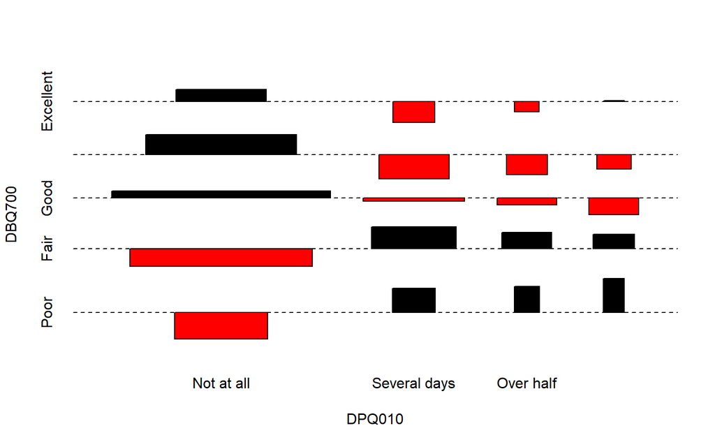

```r
assocplot(table_e)
```

## 7.4 Conclusion

Based on the analysis above, there may be reason to believe there is an association between how healthy a diet is and degree of motivation throughout the day. Higher observed frequencies were present within the cells that support this hypothesis. Higher frequencies are observed where both diet is good and motivation is high, as well as where diet is poor and motivation is low.

The results to this analysis definitely make sense to me, however they may have been too expected. I think it is a safe assumption to think that individuals with greater motivation are more likely to eat healthy, since this decision in itself required motivation. This analysis also cannot look at which factor can be deemed the predictor and the outcome. Are people eating healthy because they are motivated, or are people motivated because they are eating healthy? This study could be added to by adding temporality and controlling diets to see how motivation changes.